# Loan Eligibility Dataset

- . Problem Description.
- . Dataset Description.

## Feature Enginnering

### Feature PreProcessiong

1. Features Description
   - Mean ,STD ,min ,max ,mode
   - Histogram ,boxplot
2. Features Cleaning
   - missing values fill
   - noise identification
3. Features Transformation
   - transforming Category (string) to Numeerics values
4. Features Normalizing
   - Standarizing the Numerical values for SVM & KNN

### Feature Selection

1. Correlation-based feature ranking
   - we plot a heatmap for the correlation between each two pair of the feature
   - measure the relation between each feature and the target

## Training Approach

### for each ML algorithe (SVM , DT , KNN)

1. Model Description
2. train a model for the default hyperparameter values
3. Model Training
4. Hyper parameter tuning through grid search

## Choosing the Best Model

1. test the models of (SVM, KNN, DT) on the Testing data
2. evaluate classification report (Pr,Re,Acc,F1)
3. choose the best one based on the best F1 score

## Problem Description:

- there are an significant need for many companies an banks that specialize in providing home loans.
- in this dataswet the company operate in diverse areas, including urban, semi-urban, and rural regions.
- When a customer applies for a home loan, the company needs to assess the customer's eligibility for the loan.
- the eligiblity for the loan based on various details provided in the online application form.
- The customer(the applicant for the loan) details include:

  ```
  . Gender      . Marital              . Status
  . Education   . Number of Dependent  . Income
  . Loan Amount . Credit History       . Others
  ```

- the main purpose is To streamline and automate the loan eligibility process in real-time,
- The goal is to identify specific customer segments that are eligible for a loan amount.
- By doing so, the company aims to target these eligible customers more efficiently.

## About the dataset

- this dataset contains information about loan eligibility
- we can describe the dataset as folows :
- it contains 614 rows
- it contains 13 columns
- the columns are as follows :
  1. **Loan ID** : Unique identifier for each loan.(its not important for our analysis ).
  2. **Gender**: Categorical variable indicating the gender of the loan applicant.
  3. **Married**: Categorical variable indicating the marital status of the loan applicant.
  4. **Dependents**: Numeric variable representing the number of dependents the loan applicant has.
  5. **Education**: Categorical variable indicating the educational level of the loan applicant.
  6. **Self Employed**: indicated whether the loan applicant is self-employed. (y/n)
  7. **ApplicantIncome**: Numeric variable representing the income of the loan applicant.
  8. **Co applicant Income**: Numeric variable representing the income of the co-applicant (if any).
  9. **Loan Amount**: Numeric variable representing the loan amount.
  10. **Loan Amount Term**: Numeric variable representing the term of the loan in months.
  11. **Credit History**: indicate whether the credit history of the applicant meets the guidelines.
  12. **Property Area**:indicate the area where the property is located. can be Urban, Semi-Urban ,Rural.
  13. **Loan_Status**: variable indicate whether the loan was approved. Y (approved) or N (not approved).

## Statistics and Results

##### after doing some statistics on the dataset we get the folowing reults

- the percentage of the rejected loans is about 30%
- the percentage of the accepted loans is about 70%
- the mean income of the loan applicant is about 5403
- there are some nan values in the loan amount and other feature
- we fix the nan value for the numerical fields by set it to the mean of the others values
- for the categorical fields we fill it using the mode method
- we can sumerise the datas set in the following table

| Variable Name | Description | possible value |
| --- | --- | --- |
| **Gender** | Applicant gender (Male or Female) | Male or Female |
| **Married** | Applicant marital status (Married or not married) | Married; Not Married |
| **Dependents** | Number of family members | 0 or 1 or 2 or 3+ |
| **Education** | Applicant education/qualification (graduate or not graduate) | Graduate or Under Graduate |
| **Self_Employed** | Applicant employment status (yes for self-employed, no for employed/others) | Yes or No |
| **ApplicantIncome** | Applicant's monthly salary/income | the mean is 5403 |
| **CoapplicantIncome** | Additional applicant's monthly salary/income | the mean is 1621 |
| **LoanAmount** | Loan amount | the mean is 126 |
| **Loan_Amount_Term** | The loan's repayment period (in days) | mean is 342 month |
| **Credit_History** | Records of previous credit history (0: bad credit history, 1: good credit history) | 0 or 1 |
| **Property_Area** | The location of property (Rural/Semiurban/Urban) | Rural or Semiurban or Urban |
| **Loan_Status** | indecate the loan approvement | Y accetped or N rejected |

# Feature Engineering Stage

##### Loading Libraries

```python
import matplotlib.pyplot as plt
import seaborn as sns
import pandas as pd
from sklearn.tree import DecisionTreeClassifier
from sklearn.model_selection import train_test_split
from sklearn import metrics

from sklearn.tree import export_graphviz
import numpy as np
from io import StringIO
from sklearn.metrics import classification_report
from sklearn.metrics import confusion_matrix

from sklearn.metrics import accuracy_score
from sklearn.metrics import precision_score

from IPython.display import Image
import pydotplus
from sklearn.preprocessing import LabelEncoder
from sklearn.model_selection import GridSearchCV
from sklearn.model_selection import KFold
from sklearn.model_selection import cross_val_score
import warnings
warnings.filterwarnings('ignore')
from sklearn.neighbors import KNeighborsClassifier
from sklearn.svm import SVC
from sklearn.preprocessing import KBinsDiscretizer
```

##### Loading dataset

```
1. read dataset as csv file
2. show  column names
3. show first 5 rows
```

```python
dataFrame =pd.read_csv('C:\\Users\\HASAN\\\Desktop\\ML_HW_G\\loan-train.csv')

#show the first 5 rows for instance
dataFrame.head(5)
```

|  | Loan_ID | Gender | Married | Dependents | Education | Self_Employed | ApplicantIncome | CoapplicantIncome | LoanAmount | Loan_Amount_Term | Credit_History | Property_Area | Loan_Status |
| --- | --- | --- | --- | --- | --- | --- | --- | --- | --- | --- | --- | --- | --- |
| 0 | LP001002 | Male | No | 0 | Graduate | No | 5849 | 0.0 | NaN | 360.0 | 1.0 | Urban | Y |
| 1 | LP001003 | Male | Yes | 1 | Graduate | No | 4583 | 1508.0 | 128.0 | 360.0 | 1.0 | Rural | N |
| 2 | LP001005 | Male | Yes | 0 | Graduate | Yes | 3000 | 0.0 | 66.0 | 360.0 | 1.0 | Urban | Y |
| 3 | LP001006 | Male | Yes | 0 | Not Graduate | No | 2583 | 2358.0 | 120.0 | 360.0 | 1.0 | Urban | Y |
| 4 | LP001008 | Male | No | 0 | Graduate | No | 6000 | 0.0 | 141.0 | 360.0 | 1.0 | Urban | Y |

## - for shorter name and readable

```python
columns =['LoanID', 'Gender', 'Married', 'Dependents', 'Education',
       'SelfEmployed', 'ApplicantIncome', 'CoapplicantIncome', 'LoanAmount',
       'LoanAmountTerm', 'CreditHistory', 'PropertyArea', 'target']
dataFrame.columns= columns
```

## General information about the data

```python
print(f'the shape of the data frame is {dataFrame.shape } , rows : {dataFrame.shape[0]} , columns : {dataFrame.shape[1]}\n\n')
```

```
the shape of the data frame is (614, 13) , rows : 614 , columns : 13
```

- we notice that there are some missing values

```python
print(f'the information of the data frame is ')

dataFrame.info()
```

```
the information of the data frame is
<class 'pandas.core.frame.DataFrame'>
RangeIndex: 614 entries, 0 to 613
Data columns (total 13 columns):
 #   Column             Non-Null Count  Dtype
---  ------             --------------  -----
 0   LoanID             614 non-null    object
 1   Gender             601 non-null    object
 2   Married            611 non-null    object
 3   Dependents         599 non-null    object
 4   Education          614 non-null    object
 5   SelfEmployed       582 non-null    object
 6   ApplicantIncome    614 non-null    int64
 7   CoapplicantIncome  614 non-null    float64
 8   LoanAmount         592 non-null    float64
 9   LoanAmountTerm     600 non-null    float64
 10  CreditHistory      564 non-null    float64
 11  PropertyArea       614 non-null    object
 12  target             614 non-null    object
dtypes: float64(4), int64(1), object(8)
memory usage: 62.5+ KB
```

### Droping the unrlated feature

- we have one column (Loan Id ) is an related
- we should drop it
1. drop the id column

```python
dataFrame = dataFrame.drop('LoanID',axis = 1)
```

- we have Applicant income and Co applicant income , loan ammount ,loanammount term as a numerical features
- we have Gender and Married ,Dependents ,Education ,Employeed ,Credit history as a categorical features

```python
numerical_columns = [  'ApplicantIncome', 'CoapplicantIncome', 'LoanAmount',
                       'LoanAmountTerm'
                    ]

categorical_columns = [ 'Gender', 'Married', 'Dependents', 'Education',
                        'SelfEmployed', 'CreditHistory', 'PropertyArea','LoanAmountTerm'
                     ]
```

## Feature Description & Plot

### Categorical features :

[output not shown]

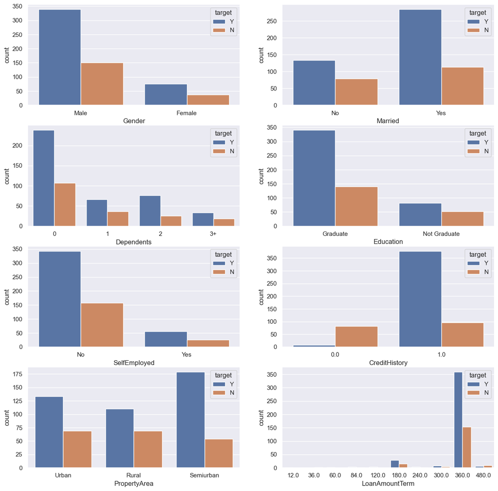

```python
figure ,axes = plt.subplots(4,2,figsize=(15,15))
for index,categorical_col in enumerate(categorical_columns):
    row,col = index//2,index%2
    sns.countplot(x=categorical_col,data=dataFrame,hue='target',ax=axes[row,col])
```

## - there are no a clear threshold for the variables to quantiz them (we let the quantization if nescesary to the model)

```python
Q1= dataFrame[['ApplicantIncome','CoapplicantIncome']].quantile(0.25)
Q3 = dataFrame[['ApplicantIncome','CoapplicantIncome']].quantile(0.75)
IQR = Q3 - Q1

dataFrame = dataFrame[~((dataFrame[['ApplicantIncome','CoapplicantIncome']] < (Q1 - 1.5 * IQR)) |
                        (dataFrame[['ApplicantIncome','CoapplicantIncome']] > (Q3 + 1.5 * IQR))).any(axis=1)]
```

[figure not shown]

```python
#dataFrame.ApplicantIncome=round((dataFrame.ApplicantIncome/300),0)*300
sns.set(style="darkgrid")
fig, axs = plt.subplots(2, 2, figsize=(10, 8))

sns.histplot(data=dataFrame, x="CoapplicantIncome", kde=True, ax=axs[1, 0], color='skyblue')
sns.histplot(data=dataFrame, x="LoanAmount", kde=True, ax=axs[0, 1], color='orange')

sns.histplot(data=dataFrame, x="ApplicantIncome", kde=True, ax=axs[0, 0], color='green')
sns.histplot(data=dataFrame, x="LoanAmountTerm", kde=True, ax=axs[1, 1], color='orange')
```

### How the numerical feature distributed due to target

### Loan ammount :

```
- the mean of the distribution fo the loan ammount ofpositive target is near to the mean of the distribution of the loan ammount of negative target
- this means that the loan anmmount and the target will be uncorrelated
- this will make it un efficient to  thresholding and lead to un good result in Decision Tree
```

[figure not shown]

```python
sns.boxplot(x="target", y="LoanAmount", data=dataFrame, palette="mako")
```

### Applicant income :

[output not shown]

[figure not shown]

```python
sns.boxplot(x="target", y="ApplicantIncome", data=dataFrame, palette='rocket');
```

```
[]
```

[figure not shown]

```python
plt.hist(dataFrame[dataFrame['target']=='N']['ApplicantIncome'], bins=35, alpha=0.45, color='red')
plt.hist(dataFrame[dataFrame['target']=='Y']['ApplicantIncome'], bins=35, alpha=0.45, color='blue')
plt.plot()
```

### CoApplicant Incom :

```python
dataFrame.CoapplicantIncome=round(dataFrame.CoapplicantIncome/220,0)*220
dataFrame.CoapplicantIncome.value_counts()
```

[output not shown]

[figure not shown]

```python
sns.boxplot(data=dataFrame.CoapplicantIncome)
```

[figure not shown]

```python
sns.boxplot(x="target", y="CoapplicantIncome", data=dataFrame, palette="mako");
```

```
[]
```

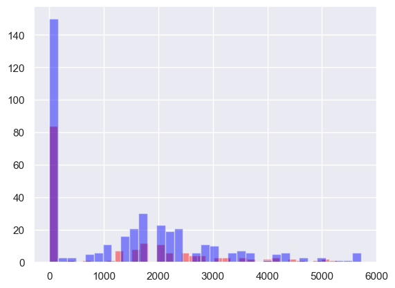

```python
plt.hist(dataFrame[dataFrame['target']=='N']['CoapplicantIncome'], bins=35, alpha=0.45, color='red')
plt.hist(dataFrame[dataFrame['target']=='Y']['CoapplicantIncome'], bins=35, alpha=0.45, color='blue')

plt.plot()
```

### Loan Amount

```python
dataFrame.CoapplicantIncome=round(dataFrame.CoapplicantIncome/260,0)*260
dataFrame.LoanAmount.value_counts()
```

```
120.0    19
110.0    16
100.0    15
128.0    11
160.0    11
         ..
207.0     1
330.0     1
280.0     1
42.0      1
253.0     1
Name: LoanAmount, Length: 172, dtype: int64
```

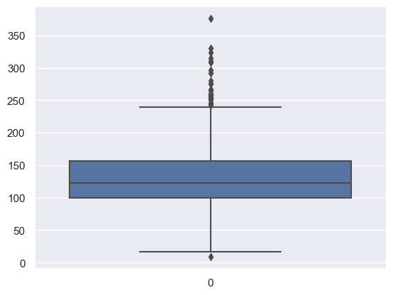

```python
# box plot for loan amount
sns.boxplot(data=dataFrame.LoanAmount)
```

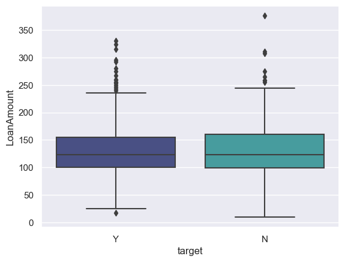

```python
sns.boxplot(x="target", y="LoanAmount", data=dataFrame, palette="mako");
```

```
[]
```

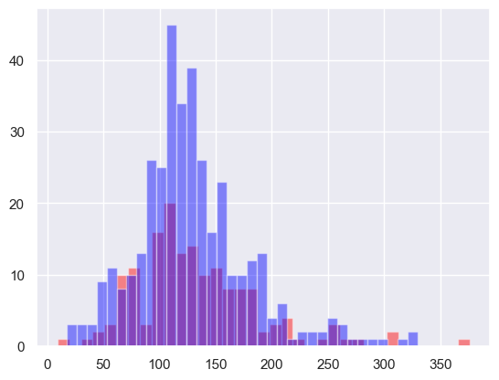

```python
plt.hist(dataFrame[dataFrame['target']=='N']['LoanAmount'], bins=35, alpha=0.45, color='red')
plt.hist(dataFrame[dataFrame['target']=='Y']['LoanAmount'], bins=35, alpha=0.45, color='blue')

plt.plot()
```

## Categorical Features : Cleaning & Transforming

```
1. Missing Values fiill
2. Transforming categorical features into numerical features

* whne we fil the Null values we replace it with the mode
```

### Gender column

```python
dataFrame.Gender.value_counts()
```

```
Male      437
Female    101
Name: Gender, dtype: int64
```

```python
dataFrame.Gender.isnull().sum()
```

```
10
```

```python
dataFrame['Gender'] = dataFrame['Gender'].map({'Female': 0, 'Male': 1})

# replace the null values with the mode
dataFrame.Gender.fillna(dataFrame.Gender.mode()[0], inplace=True)
```

### Education Feature

[output not shown]

```python
dataFrame.Education.value_counts()
```

```
Graduate        417
Not Graduate    131
Name: Education, dtype: int64
```

```python
dataFrame.Education = dataFrame.Education.map({'Graduate': 1, 'Not Graduate': 0})
```

### Married Feature

```
- 65 % of Applicants are Married
- 35 % of Applicants are Single
- Null values are 3
- we replace null values with Married [its the mode value]
- we transform the values in 0 and 1
```

```python
dataFrame.Married.value_counts()
```

```
Yes    353
No     192
Name: Married, dtype: int64
```

```python
dataFrame.Married = dataFrame.Married.map({'Yes': 1, 'No': 0})
```

```python
dataFrame.Married.fillna(dataFrame.Gender.mode()[0], inplace=True)
```

### Dependents Feature

[output not shown]

```python
dataFrame.Dependents.value_counts()
```

```
0     314
2      91
1      87
3+     42
Name: Dependents, dtype: int64
```

```python
dataFrame['Dependents'] = dataFrame['Dependents'].astype(str)

dataFrame['Dependents'].fillna(dataFrame['Dependents'].mode()[0], inplace=True)
```

### credit hisstory

```python
dataFrame.CreditHistory=dataFrame.CreditHistory.fillna(1)
```

```python
round(dataFrame.describe(),2)
```

|  | Gender | Married | Education | ApplicantIncome | CoapplicantIncome | LoanAmount | LoanAmountTerm | CreditHistory |
| --- | --- | --- | --- | --- | --- | --- | --- | --- |
| count | 548.00 | 548.00 | 548.00 | 548.00 | 548.00 | 528.00 | 534.00 | 548.00 |
| mean | 0.82 | 0.65 | 0.76 | 4128.98 | 1362.15 | 130.60 | 342.58 | 0.86 |
| std | 0.39 | 0.48 | 0.43 | 1907.40 | 1462.00 | 52.53 | 65.52 | 0.35 |
| min | 0.00 | 0.00 | 0.00 | 150.00 | 0.00 | 9.00 | 12.00 | 0.00 |
| 25% | 1.00 | 0.00 | 1.00 | 2768.75 | 0.00 | 100.00 | 360.00 | 1.00 |
| 50% | 1.00 | 1.00 | 1.00 | 3656.00 | 1300.00 | 123.00 | 360.00 | 1.00 |
| 75% | 1.00 | 1.00 | 1.00 | 5000.00 | 2080.00 | 157.00 | 360.00 | 1.00 |
| max | 1.00 | 1.00 | 1.00 | 10139.00 | 5720.00 | 376.00 | 480.00 | 1.00 |

### Cleaning the reminded feature

```
-
```

```python
### transform the rest of the feature to numeric

le = LabelEncoder()

for f in categorical_columns:
    dataFrame[f] = le.fit_transform(dataFrame[f])
    # replcae na with mode
    dataFrame[f] = dataFrame[f].fillna(dataFrame[f].mode()[0])
dataFrame.LoanAmount = dataFrame.LoanAmount.fillna(dataFrame.LoanAmount.mean())
```

```python
round(dataFrame.head(),2)
```

|  | Gender | Married | Dependents | Education | SelfEmployed | ApplicantIncome | CoapplicantIncome | LoanAmount | LoanAmountTerm | CreditHistory | PropertyArea | target |
| --- | --- | --- | --- | --- | --- | --- | --- | --- | --- | --- | --- | --- |
| 0 | 1 | 0 | 0 | 1 | 0 | 5849 | 0.0 | 130.6 | 8 | 1 | 2 | Y |
| 1 | 1 | 1 | 1 | 1 | 0 | 4583 | 1560.0 | 128.0 | 8 | 1 | 0 | N |
| 2 | 1 | 1 | 0 | 1 | 1 | 3000 | 0.0 | 66.0 | 8 | 1 | 2 | Y |
| 3 | 1 | 1 | 0 | 0 | 0 | 2583 | 2340.0 | 120.0 | 8 | 1 | 2 | Y |
| 4 | 1 | 0 | 0 | 1 | 0 | 6000 | 0.0 | 141.0 | 8 | 1 | 2 | Y |

```python
kbd = KBinsDiscretizer(n_bins=10,  encode='ordinal',strategy='kmeans')

# Fit and transform the 'LoanAmount' column
dataFrame['LoanAmount'] = kbd.fit_transform(dataFrame[['LoanAmount']])
```

```python
kbd = KBinsDiscretizer(n_bins=20, encode='ordinal',strategy='kmeans')

# Fit and transform the 'LoanAmount' column
dataFrame['LoanAmount'] = kbd.fit_transform(dataFrame[['LoanAmount']])
```

```python
kbd = KBinsDiscretizer(n_bins=15, encode='ordinal',strategy='kmeans')

# Fit and transform the 'LoanAmount' column
dataFrame['CoapplicantIncome'] = kbd.fit_transform(dataFrame[['CoapplicantIncome']])
```

#### map the target class from {Y,N} to {1,0}

```python
# transfor yes no to 1 0 in target
dataFrame.target = dataFrame.target.map({'Y': 1 , 'N':0})
```

- at the end of this stage we replace all the na values
- we replace the null values by the mode because our null values are in category feautre

```python
dataFrame.isnull().sum()
```

```
Gender               0
Married              0
Dependents           0
Education            0
SelfEmployed         0
ApplicantIncome      0
CoapplicantIncome    0
LoanAmount           0
LoanAmountTerm       0
CreditHistory        0
PropertyArea         0
target               0
dtype: int64
```

### Numerical Feature :Scaling

```python
scaled_columns =[ 'Dependents', 'ApplicantIncome', 'CoapplicantIncome', 'LoanAmount',
       'LoanAmountTerm','PropertyArea']
```

```python
for feature in scaled_columns:
    dataFrame[feature] = (dataFrame[feature] - dataFrame[feature].mean()) /(dataFrame[feature].max()-dataFrame[feature].min())
```

```python
round(dataFrame[scaled_columns].describe(),2)
```

|  | Dependents | ApplicantIncome | CoapplicantIncome | LoanAmount | LoanAmountTerm | PropertyArea |
| --- | --- | --- | --- | --- | --- | --- |
| count | 548.00 | 548.00 | 548.00 | 548.00 | 548.00 | 548.00 |
| mean | 0.00 | 0.00 | -0.00 | 0.00 | -0.00 | 0.00 |
| std | 0.28 | 0.19 | 0.26 | 0.17 | 0.12 | 0.39 |
| min | -0.21 | -0.40 | -0.24 | -0.38 | -0.77 | -0.51 |
| 25% | -0.21 | -0.14 | -0.24 | -0.08 | 0.03 | -0.51 |
| 50% | -0.21 | -0.05 | -0.02 | 0.02 | 0.03 | -0.01 |
| 75% | 0.29 | 0.09 | 0.12 | 0.12 | 0.03 | 0.49 |
| max | 0.79 | 0.60 | 0.76 | 0.62 | 0.23 | 0.49 |

#### numerical columns after scaling

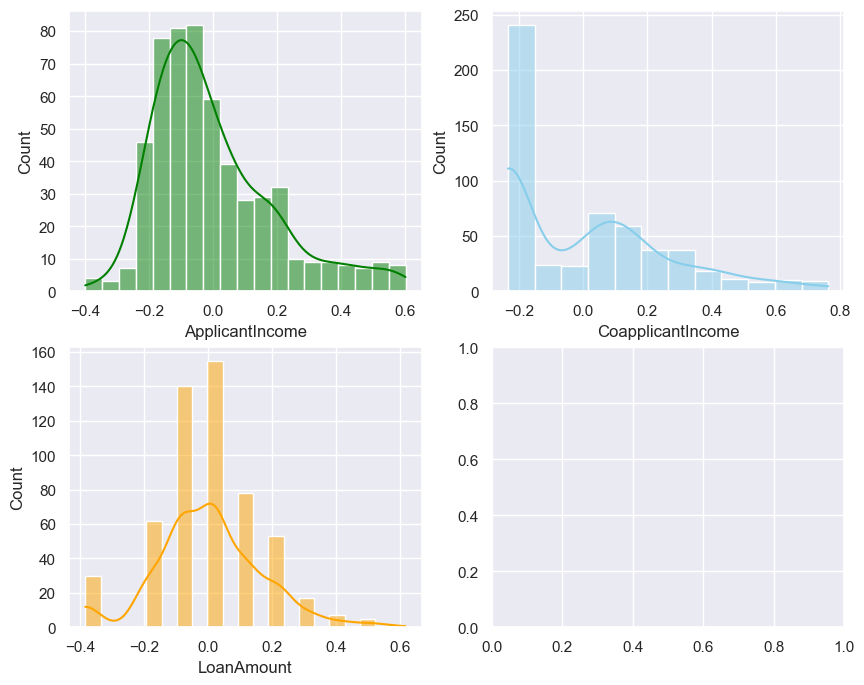

```python
#plotting the distribution of the numerical variables
sns.set(style="darkgrid")
fig, axs = plt.subplots(2, 2, figsize=(10, 8))

sns.histplot(data=dataFrame, x="ApplicantIncome", kde=True, ax=axs[0, 0], color='green')
sns.histplot(data=dataFrame, x="CoapplicantIncome", kde=True, ax=axs[0, 1], color='skyblue')
sns.histplot(data=dataFrame, x="LoanAmount", kde=True, ax=axs[1, 0], color='orange')
```

## heat map

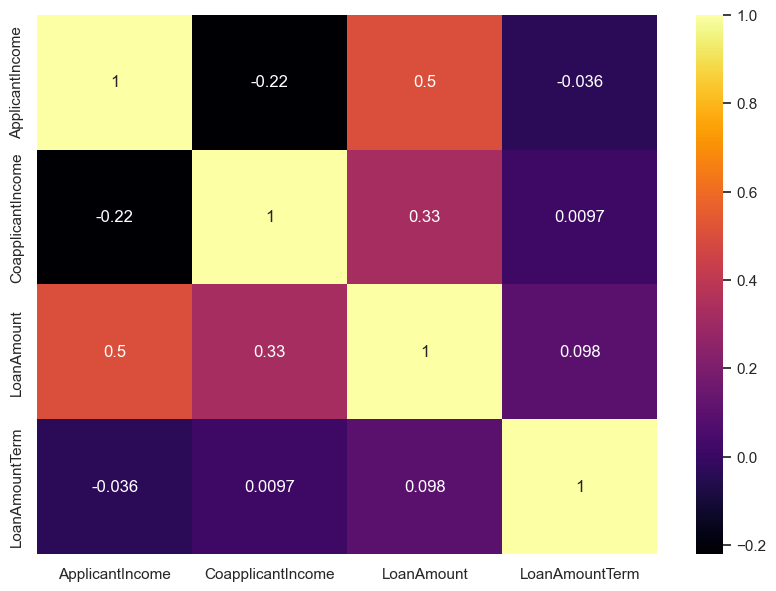

```python
numeric_columns = dataFrame[numerical_columns]
plt.figure(figsize=(10,7))
sns.heatmap(numeric_columns.corr(), annot=True, cmap='inferno')
```

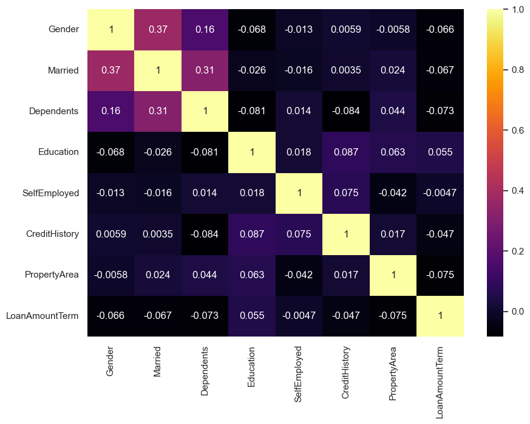

```python
numeric_columns = dataFrame[categorical_columns]
plt.figure(figsize=(10,7))
sns.heatmap(numeric_columns.corr(), annot=True, cmap='inferno')
```

## splitting the data

#### split the data frame to X and Y

```python
X=dataFrame.drop('target',axis=1)
#X.drop('CreditHistory',axis=1,inplace=True)
Y=dataFrame['target']
```

```python
round(X.head(),2)
```

|  | Gender | Married | Dependents | Education | SelfEmployed | ApplicantIncome | CoapplicantIncome | LoanAmount | LoanAmountTerm | CreditHistory | PropertyArea |
| --- | --- | --- | --- | --- | --- | --- | --- | --- | --- | --- | --- |
| 0 | 1 | 0 | -0.21 | 1 | 0 | 0.17 | -0.24 | 0.02 | 0.03 | 1 | 0.49 |
| 1 | 1 | 1 | 0.04 | 1 | 0 | 0.05 | 0.05 | 0.02 | 0.03 | 1 | -0.51 |
| 2 | 1 | 1 | -0.21 | 1 | 1 | -0.11 | -0.24 | -0.18 | 0.03 | 1 | 0.49 |
| 3 | 1 | 1 | -0.21 | 0 | 0 | -0.15 | 0.19 | 0.02 | 0.03 | 1 | 0.49 |
| 4 | 1 | 0 | -0.21 | 1 | 0 | 0.19 | -0.24 | 0.02 | 0.03 | 1 | 0.49 |

### Split the X to train , validation and test

```
- we split the dataset to 70 % training and 30 % testing
-
```

```python
# split the data to train and test
from imblearn.over_sampling import SMOTE
#X,Y=SMOTE().fit_resample(X,Y)
X_train ,X_test,y_train , y_test =train_test_split(X,Y,test_size=0.3,random_state=47)
```

### Null Accuracy

```python
print('training Null Acuracy  : ' , len(y_train[y_train == 1] )/(len(y_train)))

print('\n\ntesting Null Accuracy', len(y_test[y_test == 1] )/(len(y_test)))

print('\n\nover all the dataset  Null Accuracy', len(Y[Y == 1] )/(len(Y)))
```

```
training Null Acuracy  :  0.6892950391644909


testing Null Accuracy 0.703030303030303


over all the dataset  Null Accuracy 0.6934306569343066
```

## Training Approach

```
- in this part we will train a model for each model of (SVM ,DT ,KNN)
- we will tune the hyper parameter of it through grid search
- we will evaluate it on the testing set
```

## Decision Tree Classifier

```python
# Initialize the Decision Tree Classifier with possible parameters for tuning
parameters = {
    'max_depth': [7,14,8,10,16,20],
    'min_samples_split': [10,15,12],
    'min_samples_leaf': [5,8,10,12,1],
    'criterion': ['gini', 'entropy']
}

o_DT_grid_search = GridSearchCV(DecisionTreeClassifier(criterion='entropy'), parameters,scoring='f1', cv=5)
o_DT_grid_search.fit(X_train, y_train)
```

```
GridSearchCV(cv=5, estimator=DecisionTreeClassifier(criterion='entropy'),
             param_grid={'criterion': ['gini', 'entropy'],
                         'max_depth': [7, 14, 8, 10, 16, 20],
                         'min_samples_leaf': [5, 8, 10, 12, 1],
                         'min_samples_split': [10, 15, 12]},
             scoring='f1')
```

The best hper parameter for the Dt are

```python
print(f'Best parameters: {o_DT_grid_search.best_params_}')
```

```
Best parameters: {'criterion': 'gini', 'max_depth': 7, 'min_samples_leaf': 12, 'min_samples_split': 12}
```

```python
o_DT_y_pred = o_DT_grid_search.best_estimator_.predict(X_test)

# Evaluate the model
accuracy = accuracy_score(y_test, o_DT_y_pred)
print(f'Accuracy of DecisionTreeClassifier after scaling: {accuracy}')
```

```
Accuracy of DecisionTreeClassifier after scaling: 0.7878787878787878
```

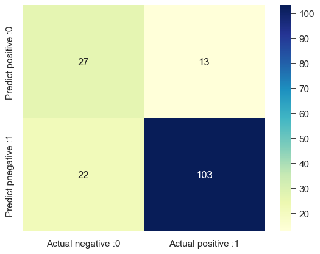

```python
cm=  confusion_matrix(o_DT_y_pred,y_test)
cm_matrix = pd.DataFrame(data=cm,columns=['Actual negative :0','Actual positive :1']
                         ,index=['Predict positive :0','Predict pnegative :1'])
sns.heatmap(cm_matrix,annot=True,fmt='d',cmap='YlGnBu')
```

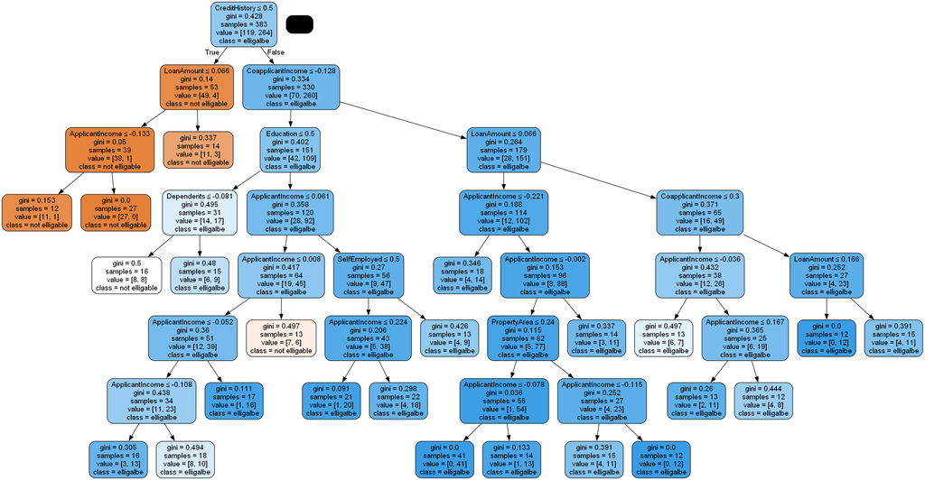

```python
dot_data = StringIO()
export_graphviz(o_DT_grid_search.best_estimator_, out_file=dot_data,
                filled=True, rounded=True,
                special_characters=True,feature_names = X.columns ,class_names=['not elligable','elligalbe'])
graph = pydotplus.graph_from_dot_data(dot_data.getvalue())
graph.write_png('loan9.png')
Image(graph.create_png())
```

### Grid search with Precision score

```python
from sklearn.metrics import precision_score, make_scorer,recall_score,f1_score
custom_scorer = make_scorer(precision_score, greater_is_better=True,  pos_label=0)
```

```python
# Initialize the Decision Tree Classifier with possible parameters for tuning
parameters = {
    'max_depth': [7 ,10,15,13,15,30],
    'min_samples_split': [35,45,50,60],
    'min_samples_leaf': [10,20,15]
}
DT_grid_search = GridSearchCV(DecisionTreeClassifier(criterion='entropy'), parameters, cv=5,scoring=custom_scorer)
DT_grid_search.fit(X_train, y_train)
```

```
GridSearchCV(cv=5, estimator=DecisionTreeClassifier(criterion='entropy'),
             param_grid={'max_depth': [7, 10, 15, 13, 15, 30],
                         'min_samples_leaf': [10, 20, 15],
                         'min_samples_split': [35, 45, 50, 60]},
             scoring=make_scorer(precision_score, pos_label=0))
```

```python
print(DT_grid_search.best_params_)
```

```
{'max_depth': 7, 'min_samples_leaf': 10, 'min_samples_split': 60}
```

```python
DT_y_pred = DT_grid_search.best_estimator_.predict(X_test)

# Evaluate the model
accuracy = accuracy_score(y_test, DT_y_pred)

precision = precision_score(y_test, DT_y_pred)

print(classification_report(y_test, DT_y_pred))
```

```
              precision    recall  f1-score   support

           0       0.89      0.51      0.65        49
           1       0.82      0.97      0.89       116

    accuracy                           0.84       165
   macro avg       0.86      0.74      0.77       165
weighted avg       0.85      0.84      0.82       165
```

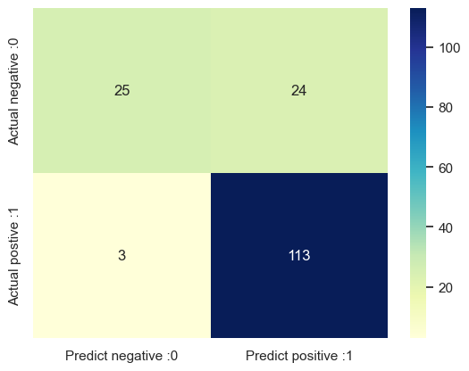

```python
cm=  confusion_matrix(y_test,DT_y_pred)
cm_matrix = pd.DataFrame(data=cm,columns=['Predict negative :0','Predict positive :1']
                         ,index=['Actual negative :0','Actual postive :1'])
sns.heatmap(cm_matrix,annot=True,fmt='d',cmap='YlGnBu')
```

### ploting the best DT model

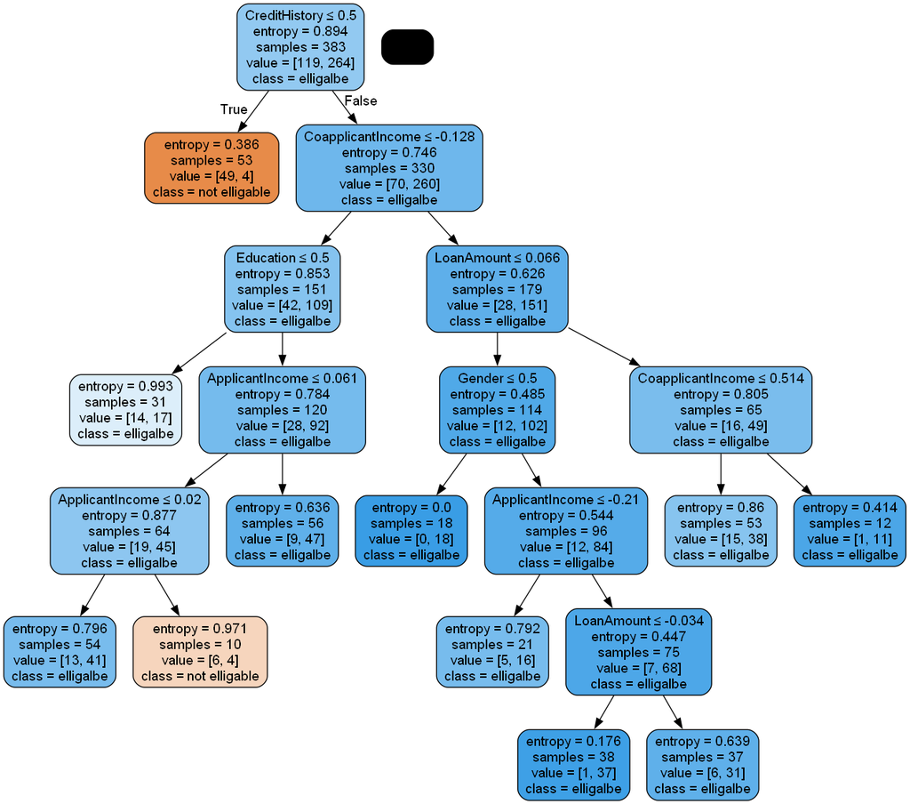

```python
dot_data = StringIO()
export_graphviz(DT_grid_search.best_estimator_, out_file=dot_data,
                filled=True, rounded=True,
                special_characters=True,feature_names = X.columns ,class_names=['not elligable','elligalbe'])
graph = pydotplus.graph_from_dot_data(dot_data.getvalue())
graph.write_png('loan10.png')
Image(graph.create_png())
```

## svm for default values

```python
svc=SVC()
svc.fit(X_train,y_train)
y_pred=svc.predict(X_test)
print("Model accuracy score with default hyperparameters: {0:0.4f}".format(accuracy_score(y_test,y_pred)))
```

```
Model accuracy score with default hyperparameters: 0.8485
```

```python
svc=SVC(kernel='poly',degree=4,gamma=0.5,C=0.1)
svc.fit(X_train,y_train)
y_pred=svc.predict(X_test)
print("Model accuracy score with default hyperparameters: {0:0.4f}".format(accuracy_score(y_test,y_pred)))
```

```
Model accuracy score with default hyperparameters: 0.8364
```

```python
svc=SVC(kernel='rbf',gamma=0.8,C=100)
svc.fit(X_train,y_train)
y_pred=svc.predict(X_test)
print("Model accuracy score with default hyperparameters: {0:0.4f}".format(accuracy_score(y_test,y_pred)))
```

```
Model accuracy score with default hyperparameters: 0.7273
```

## grid search for the best linear SVM Model

```python
svc = SVC ()
parameters = [
    {'C': range(1,100,10),'kernel':['linear']}
   ]

SVM_grid_search = GridSearchCV(estimator=svc,
                          param_grid=parameters,
                          scoring=custom_scorer,
                          cv=5,
                          verbose=1)
SVM_grid_search.fit(X_train, y_train)
```

```
Fitting 5 folds for each of 10 candidates, totalling 50 fits
```

```
GridSearchCV(cv=5, estimator=SVC(),
             param_grid=[{'C': range(1, 100, 10), 'kernel': ['linear']}],
             scoring=make_scorer(precision_score, pos_label=0), verbose=1)
```

## accuracy of best hyper params for svm

```python
svm_best=SVM_grid_search.best_estimator_
```

```python
print(f'Best parameters: {SVM_grid_search.best_params_}')
```

```
Best parameters: {'C': 1, 'kernel': 'linear'}
```

```python
SVM_y_pred = SVM_grid_search.best_estimator_.predict(X_test)

# Evaluate the model
accuracy = accuracy_score(y_test, SVM_y_pred)
precision = precision_score(y_test, SVM_y_pred)

print(f'Accuracy of SVM after scaling: {accuracy}')
print(f'precisio  of SVM after scaling: {precision}')
```

```
Accuracy of SVM after scaling: 0.8484848484848485
precisio  of SVM after scaling: 0.8273381294964028
```

```python
y_test.value_counts()
```

```
1    116
0     49
Name: target, dtype: int64
```

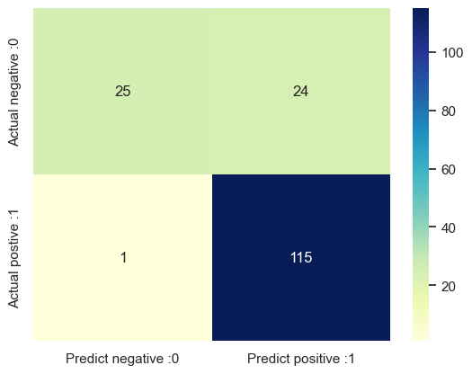

```python
cm=  confusion_matrix(y_test,SVM_y_pred)
cm_matrix = pd.DataFrame(data=cm,columns=['Predict negative :0','Predict positive :1']
                         ,index=['Actual negative :0','Actual postive :1'])
sns.heatmap(cm_matrix,annot=True,fmt='d',cmap='YlGnBu')
```

### tune ploy svm

```python
svc = SVC ()
parameters = [
    {'C':[0.1,0.2,0.4,1,2,4,10,],'kernel':['poly'], 'gamma' : [0.7,0.6,0.3,0.4,0.1],'degree':[2,3,4]}
   ]

poly_SVM_grid_search = GridSearchCV(estimator=svc,
                          param_grid=parameters,
                          scoring=custom_scorer,
                          cv=5,
                          verbose=1)
poly_SVM_grid_search.fit(X_train, y_train)
```

```
Fitting 5 folds for each of 105 candidates, totalling 525 fits
```

```
GridSearchCV(cv=5, estimator=SVC(),
             param_grid=[{'C': [0.1, 0.2, 0.4, 1, 2, 4, 10],
                          'degree': [2, 3, 4],
                          'gamma': [0.7, 0.6, 0.3, 0.4, 0.1],
                          'kernel': ['poly']}],
             scoring=make_scorer(precision_score, pos_label=0), verbose=1)
```

```python
poly_SVM_y_pred = poly_SVM_grid_search.best_estimator_.predict(X_test)

# Evaluate the model
accuracy = accuracy_score(y_test, poly_SVM_y_pred)
precision = precision_score(y_test, poly_SVM_y_pred)

print(f'Accuracy of SVM after scaling: {accuracy}')
print(f'precisio  of SVM after scaling: {precision}')
```

```
Accuracy of SVM after scaling: 0.806060606060606
precisio  of SVM after scaling: 0.7876712328767124
```

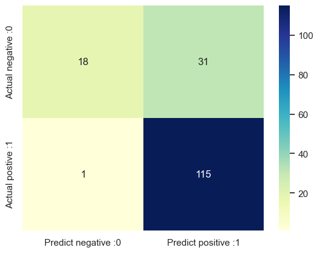

```python
cm=  confusion_matrix(y_test,poly_SVM_y_pred)
cm_matrix = pd.DataFrame(data=cm,columns=['Predict negative :0','Predict positive :1']
                         ,index=['Actual negative :0','Actual postive :1'])
sns.heatmap(cm_matrix,annot=True,fmt='d',cmap='YlGnBu')
```

# k fold cross validation

```
- we apply te KFCV to see if we get the accurracy of the svm  by chance
```

```python
kfold=KFold(n_splits=100, shuffle=True , random_state=0)
linear_svc=SVC(kernel = 'linear',C=1)
linear_scores = cross_val_score(linear_svc , X, Y , cv=kfold)
```

```python
print ('Stratified cross-validition scores with linear kernel:\n\n{}'.format(linear_scores.mean()))
```

```
Stratified cross-validition scores with linear kernel:

0.8203333333333334
```

## KNN

```python
knn = KNeighborsClassifier(n_neighbors = 3)
knn.fit(X_train, y_train)
```

```
KNeighborsClassifier(n_neighbors=3)
```

```python
knn_y_pred = knn.predict(X_test)

accuracy = accuracy_score(y_test, knn_y_pred)

print(f"KNN Model Accuracy: {accuracy:.4f}")
```

```
KNN Model Accuracy: 0.8061
```

### hyper parameer tuning

```python
from sklearn.model_selection import GridSearchCV
param_grid={'n_neighbors':range(1,40),
            'metric':['euclidean','manhattan','cosine'],
            'weights':['uniform','distance']
           }
KNN_=KNeighborsClassifier()
KNN_grid_search=GridSearchCV(estimator=KNN_,param_grid=param_grid,cv=5,scoring=custom_scorer)
```

```python
KNN_grid_search.fit(X_train,y_train)

print(KNN_grid_search.best_params_)
```

```
{'metric': 'manhattan', 'n_neighbors': 39, 'weights': 'uniform'}
```

```python
knn_y_pred = KNN_grid_search.best_estimator_.predict(X_test)

# Evaluate the model
accuracy = accuracy_score(y_test, knn_y_pred)
precision = precision_score(y_test, knn_y_pred)

print(f'Accuracy of SVM after scaling: {accuracy}')
print(f'precisio  of SVM after scaling: {precision}')
```

```
Accuracy of SVM after scaling: 0.7878787878787878
precisio  of SVM after scaling: 0.7682119205298014
```

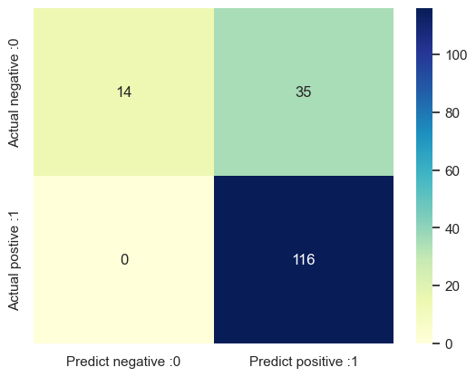

```python
cm=  confusion_matrix(y_test,knn_y_pred)
cm_matrix = pd.DataFrame(data=cm,columns=['Predict negative :0','Predict positive :1']
                         ,index=['Actual negative :0','Actual postive :1'])
sns.heatmap(cm_matrix,annot=True,fmt='d',cmap='YlGnBu')
```

### naive bayes

```python
from sklearn.naive_bayes import GaussianNB
# Initialize the Gaussian Naive Bayes model
nb = GaussianNB()

# Train the model
nb.fit(X_train, y_train)

# Make predictions
y_pred_train = nb.predict(X_train)
y_pred_test = nb.predict(X_test)
```

```python
# Evaluate the model
train_accuracy = accuracy_score(y_train, y_pred_train)
test_accuracy = accuracy_score(y_test, y_pred_test)

print(f"Training Accuracy: {train_accuracy:.4f}")
print(f"Test Accuracy: {test_accuracy:.4f}")

# Classification report
print("\nClassification Report:")
print(classification_report(y_test, y_pred_test))

# Confusion matrix
print("\nConfusion Matrix:")
print(confusion_matrix(y_test, y_pred_test))
```

```
Training Accuracy: 0.8068
Test Accuracy: 0.8485

Classification Report:
              precision    recall  f1-score   support

           0       0.96      0.51      0.67        49
           1       0.83      0.99      0.90       116

    accuracy                           0.85       165
   macro avg       0.89      0.75      0.78       165
weighted avg       0.87      0.85      0.83       165


Confusion Matrix:
[[ 25  24]
 [  1 115]]
```

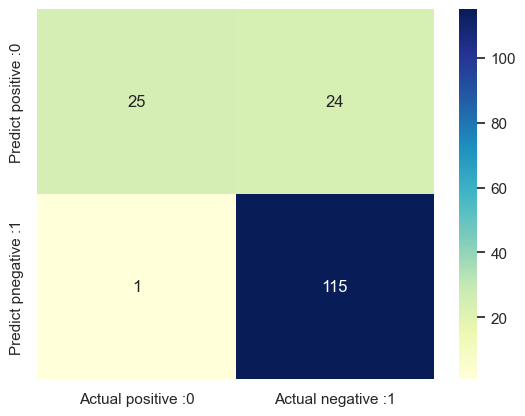

```python
cm=  confusion_matrix(y_test,y_pred_test)
cm_matrix = pd.DataFrame(data=cm,columns=['Actual positive :0','Actual negative :1']
                         ,index=['Predict positive :0','Predict pnegative :1'])
sns.heatmap(cm_matrix,annot=True,fmt='d',cmap='YlGnBu')
```

### How the best models worked on the Cross validation :

[output not shown]

### Classification report

- in our probem we are care of the Precision
- so we will choose the best model of the three model based on the precision but all the models has a near precision and diff accuraxcy so we will choose based in the F1

```python
print("\nSVM Classification Report:")

print(classification_report(y_test, SVM_y_pred))

print("\nDT  Classification Report:")

print(classification_report(y_test, DT_y_pred))

print("\nnon linera svm  Classification Report:")

print(classification_report(y_test, poly_SVM_y_pred))

print("\nKNN Classification Report:")

print(classification_report(y_test, knn_y_pred))
```

```
SVM Classification Report:
              precision    recall  f1-score   support

           0       0.96      0.51      0.67        49
           1       0.83      0.99      0.90       116

    accuracy                           0.85       165
   macro avg       0.89      0.75      0.78       165
weighted avg       0.87      0.85      0.83       165


DT  Classification Report:
              precision    recall  f1-score   support

           0       0.89      0.51      0.65        49
           1       0.82      0.97      0.89       116

    accuracy                           0.84       165
   macro avg       0.86      0.74      0.77       165
weighted avg       0.85      0.84      0.82       165


non linera svm  Classification Report:
              precision    recall  f1-score   support

           0       0.95      0.37      0.53        49
           1       0.79      0.99      0.88       116

    accuracy                           0.81       165
   macro avg       0.87      0.68      0.70       165
weighted avg       0.84      0.81      0.77       165


KNN Classification Report:
              precision    recall  f1-score   support

           0       1.00      0.29      0.44        49
           1       0.77      1.00      0.87       116

    accuracy                           0.79       165
   macro avg       0.88      0.64      0.66       165
weighted avg       0.84      0.79      0.74       165
```

## chosing the best model

[output not shown]